# A workflow for Defferential expression data analysis

Mengqi Zhang, Wei Sun

2020-01-04

# 1 Introduction

This markdown is for individual case-control study based onJensen–Shannon divergence and permanova-S distance estimation on the gene differential expression (DE) analysis of certain cell type based on simulated scRNAseq data from zero-inflated negative binomial (ZINB) distribution and compared the result with the [MAST](https://www.bioconductor.org/packages/release/bioc/html/MAST.html) packages(for scRNAseq) and the [DESeq2](https://bioconductor.org/packages/release/bioc/vignettes/DESeq2/inst/doc/DESeq2.html) packages(for bulk RNAseq)

The packages required for the analysis are as follows:

- MASS: Tools for basic statistical calculation.
- emdbook: Tools for fitting and simulating zero-inflated negative binomial(ZINB) distribution.
- moments: Tools support MAST.
- MAST: Tools for scRNAseq differential expression analysis.
- lme4: Tools support MAST.
- DESeq2: Tools for bulk RNAseq differential expression analysis.

## 1.1 initial setup

R packages required in this pipeline:

```r
library("MASS")
library("emdbook")
library("moments")
library("MAST")
library("lme4")
library("DESeq2")
```

## 1.2 functions in our analysis

R packages required in this pipeline:

```r
function_dir="/fh/fast/sun_w/mengqi/1.Testing_scRNAseq/Command/"

source(paste0(function_dir,"7.0_ZINB_fit_functions.R"))
source(paste0(function_dir,"8.0_kl_divergence_functions.R"))
source(paste0(function_dir,"9.0_Fstat_functions.R"))


####this function returns the parameters for fold change of mean and variance of the ZINB distribution
#require:  r_m/r_v <1+mu/theta
calc_zinb_param=function(mu,theta,drop=0,r_m=1,r_v=1){
  #mu=mean
  #theta=overdispersion
  mu2=r_m*mu
  theta2=theta*mu*r_m/(mu*r_v*r_m+(r_v*r_m-1)*theta + (r_v-1)*r_m*mu*drop*theta)
  if(theta2 < 0){ stop("negative theta2\n") }
  return(c(mu2,theta2))
}

# This function calcuate the parameters of 3rd NB/ZINB distribution according to a mixtured 50%-50%
# Suppose Z have equaliy probability to falls into two NB distribution ZINB(mu1,size1,drop1), ZINB(mu2,size2,drop2). Calculate Z's ZINB(mu3,size3,drop3)

#enlarge: using the input as the smaller distribution
#input:
# mu2,size2,drop2,change_proportion
# or
# mean2,size2,drop2,change_proportion

#Here we have to have some support
#output: size #size==theta in the notation
cal_nbzinb_param_multimodality_enlarge=function(mu=NA,size,drop,change_proportion=0.5, mean2=NA){
  if(is.na(mu)){
    mu=mean2/(1-drop)
  }
  if(is.na(mean2)){
    mean2=(1-drop)*mu
  }
  mean3=mean2/(1-change_proportion)
  mean1=(1+change_proportion)*mean3
  mu3=mu/(1-change_proportion)
  mu1=(1+change_proportion)*mu3
  t=mean3-mean2
  m=mean3
  size3=m^2/(m^2/size + t^2/size + t^2)
  return(size3)
}
```

# 2 Simulation

In this simulation example, we will generate 3000 genes from a particular type of cell of 20 case subjects and 20 control subjects, with each subjects have 100 cells. We simulate the basic parameters, i.e., the mean, dispersion and dropout parameter from the distribution of the real reference scRNAseq database from paper [Single-cell genomics identifies cell type–specific molecular changes in autism](https://science.sciencemag.org/content/364/6441/685.abstract).

Within this 3000 genes, we simulate 4 different type of DEs by adding on particular ratios to the basic parameters to get expected fold changes.

(1). mean DE: 300 genes are DE in mean but not in var, the genes are differential expressed in mean between cases and controls. In practice, we simulate 150 genes up-regulated in cases, and another 150 genes up-regulated in control to keep the total library size same.We implement this setting by simply change the parameter /mu and /dispersion to suit the expected fold changes in mean with the function calc_zinb_param.

(4).multimodality DE: 300 genes are DE due to Multimodality. Suppose Z have equaliy probability to falls into two NB/ZINB distribution Z1~ZINB(mu1,size1,drop1), Z2~ZINB(mu2,size2,drop2). Suppose another variable Z3~ZINB(mu3,size3,drop3), who has the same mean and variance as Z1. Then it is not too difficult to calculate the mu3,size3,drop3 with known m1, size1, drop1 and m2, size2, drop2. In practice, we simulate 150 genes are mixtured with 2 ZINB distributions in cases, and another 150 genes are mixtured with 2 ZINB distributions in control.We implement this setting by supporting the m1=m3+t, m2=m3-t, while the t equals to given proportion of m3(eg: t=0.2*m3). To avoid generating negative parameters. We will set the basic parameters as the parameters as the distribution of Z2, and then generate Z1 and Z3 according to t.

We use parameter HET to define the “mixture” situation of case conditions.f HET equals to 0, we simulate case cells from completely case condition. Otherwise, if HET equals to 1, we generate 1/2 case cells from completely case condition

## 2.1 Basic Settings

```r
#data directory
dir="/fh/fast/sun_w/mengqi/1.Testing_scRNAseq/"

r_mean=2 #fold-changes of DE mean genes
r_var=1.2#fold-changes of DE var genes
r_disp=2 #fold-changes of DE dispersion genes
r_change_prop=0.5 #DE proportion of distance from the mean of multimodality DE genes


nGeneMean=300
nGeneVar=300
nGeneDisp=300
nGeneMult=300
nGeneBlank=1800
nGeneTotal=nGeneMean+nGeneVar+nGeneMult+nGeneDisp+nGeneBlank
ncase=20   #cases number
nctrl=20   #control number
ncell=100  #cell number of cases and controls
nall=ncase+nctrl

HET=0 #0/1 label: if HET==0, generate case cells from completely case condition
      #           if HET==1, generate 1/2 case cells from completely case condition

i_mean=1:nGeneMean
i_var=(nGeneMean+1):(nGeneMean+nGeneVar)
i_disp=(nGeneMean+nGeneVar+1):(nGeneMean+nGeneVar+nGeneDisp)
i_mult=(nGeneMean+nGeneVar+nGeneDisp+1):(nGeneMean+nGeneVar++nGeneDisp+nGeneMult)
i_blank=(nGeneMean+nGeneVar+nGeneDisp+nGeneMult+1):nGeneTotal

case_modify_flag=rbinom(nGeneTotal,1,0.5)
i_case_modify=which(case_modify_flag==1) #randomlized settings, switching cases and control samples to make sure the library sizes the same


#first control, then case
i_ctrl=1:(nctrl*ncell)
i_case=(nctrl*ncell+1):((ncase+nctrl)*ncell)
```

## 2.2 Simulation References Data Preparation

The reference data for simulation is from the paper [Single-cell genomics identifies cell type–specific molecular changes in autism](https://science.sciencemag.org/content/364/6441/685.abstract). Some details of their analysis is provided [here](https://science.sciencemag.org/content/suppl/2019/05/15/364.6441.685.DC1). Specifically, we do some basic data cleaning and processing. Then we take the first 3K genes who expressed in the most cells, and we randomly take 10 percentage of the single cells among all cells in the dataset. After this step, the data was denoised with [DCA](https://github.com/theislab/dca) package, a software to denoise the scRNAseq counts with autoencoder, an artificial neural network used to learn efficient data codings in an unsupervised manner.The input rawM3k10.csv includes a CSV/TSV-formatted raw count matrix with genes in rows and cells in columns.

```bash
dca rawM3k10.csv res_dca_rawM3k10/
```

The output of DCA is an estimation of the expression of each gene and each cell in an ZINB distribution, which includes the estimation of the mean, dropout probabilities and dispersion for each cell and gene as an the ZINB distribution. In our simulation, we will borrow the parameters from the ouput of DCA.

Note: DCA itself includes the size factor of each cells in its pipelines.Thus the input of DCA should be the raw count data without any normalization or log transformation.

```r
dca_dir="/fh/fast/sun_w/mengqi/Data_PRJNA434002/res_dca_rawM3k10/"

# files from DCA
t_mean = read.table(paste0(dca_dir,"mean_signif4.tsv.gz"),
                    sep = "\t", header = TRUE)

t_disp = read.table(paste0(dca_dir,"dispersion_signif4.tsv.gz"),
                    sep = "\t", header = TRUE)

t_drop = read.table(paste0(dca_dir,"dropout_signif4.tsv.gz"),
                    sep = "\t", header = TRUE)

dim(t_mean)
```

```
## [1]  3000 10455
```

```r
t_mean[1:2,1:5]
```

```
##           AAAGTAGGTAGCCTCG.1_1823_BA24 AACCATGGTCTAAAGA.1_1823_BA24
## MALAT1                          30.610                       36.610
## LINC00486                        4.188                        8.041
##           AACTTTCTCGGCTACG.1_1823_BA24 AAGGTTCCATGGTTGT.1_1823_BA24
## MALAT1                          23.950                        96.50
## LINC00486                        2.385                        21.26
##           ACACCAATCTCTGAGA.1_1823_BA24
## MALAT1                          31.580
## LINC00486                        5.104
```

```r
dim(t_disp)
```

```
## [1]  3000 10455
```

```r
t_disp[1:2,1:5]
```

```
##           AAAGTAGGTAGCCTCG.1_1823_BA24 AACCATGGTCTAAAGA.1_1823_BA24
## MALAT1                           6.762                        7.033
## LINC00486                        4.487                        7.760
##           AACTTTCTCGGCTACG.1_1823_BA24 AAGGTTCCATGGTTGT.1_1823_BA24
## MALAT1                           5.798                        7.803
## LINC00486                        4.248                        8.890
##           ACACCAATCTCTGAGA.1_1823_BA24
## MALAT1                           6.564
## LINC00486                        4.015
```

```r
dim(t_drop)
```

```
## [1]  3000 10455
```

```r
t_drop[1:2,1:5]
```

```
##           AAAGTAGGTAGCCTCG.1_1823_BA24 AACCATGGTCTAAAGA.1_1823_BA24
## MALAT1                         3.0e-06                      1.1e-05
## LINC00486                      1.1e-05                      2.4e-05
##           AACTTTCTCGGCTACG.1_1823_BA24 AAGGTTCCATGGTTGT.1_1823_BA24
## MALAT1                           9e-06                      2.2e-05
## LINC00486                        3e-05                      3.3e-05
##           ACACCAATCTCTGAGA.1_1823_BA24
## MALAT1                         5.0e-06
## LINC00486                      1.6e-05
```

```r
## Collect sample information

col_info   = strsplit(names(t_mean), split="_")
sample_ids = sapply(col_info, function(x){paste(x[-1], collapse="_")})
table(sample_ids)
```

```
## sample_ids
##     1823_BA24     4341_BA24     4341_BA46     4849_BA24     4899_BA24
##            84           329           385           387           301
##      5144_PFC     5163_BA24     5242_BA24     5278_BA24      5278_PFC
##           204           148           309           166           282
##     5294_BA24      5294_BA9      5387_BA9     5391_BA24      5403_PFC
##           196           257           654           218           111
## 5408_PFC_Nova      5419_PFC     5531_BA24      5531_BA9 5538_PFC_Nova
##           225           198           140           305           303
##     5554_BA24     5565_BA24      5565_BA9      5577_BA9      5841_BA9
##           439           301           232           413           547
##      5864_BA9 5879_PFC_Nova     5893_BA24      5893_PFC 5936_PFC_Nova
##           215           185           262           332           203
##     5939_BA24      5939_BA9      5945_PFC     5958_BA24      5958_BA9
##           165           309           252           260           209
##      5976_BA9     5978_BA24      5978_BA9     6032_BA24     6033_BA24
##           105           189            92           192           154
##      6033_BA9
##           197
```

```r
tapply_mean <- function(x){tapply(x, sample_ids, mean)}
tapply_sd <- function(x){tapply(x, sample_ids, sd)}

sample_log_mean = t(apply(log(t_mean), 1, tapply_mean))
sample_disp = t(apply(t_disp, 1, tapply_mean))
sample_drop = t(apply(t_drop, 1, tapply_mean))

sample_log_mean_sd = t(apply(log(t_mean), 1, tapply_sd))

dim(sample_log_mean)
```

```
## [1] 3000   41
```

```r
dim(sample_disp)
```

```
## [1] 3000   41
```

```r
dim(sample_drop)
```

```
## [1] 3000   41
```

```r
dim(sample_log_mean_sd)
```

```
## [1] 3000   41
```

```r
sample_log_mean[1:2,1:5]
```

```
##           1823_BA24 4341_BA24 4341_BA46 4849_BA24 4899_BA24
## MALAT1     4.085084  4.864283  5.021004  4.122345  3.990273
## LINC00486  2.531741  2.349609  2.071969  1.768909  2.165021
```

```r
sample_log_mean_sd[1:2,1:5]
```

```
##           1823_BA24 4341_BA24 4341_BA46 4849_BA24 4899_BA24
## MALAT1     1.591199  1.517465  1.491507  1.856361  1.856404
## LINC00486  1.395710  1.268620  1.234744  1.308956  1.355200
```

```r
# the sd within an individual, across cells is large,
# probably becaue the cells are from different cell types
# so we reduce them by a factor of 10 here.
summary(apply(sample_log_mean, 1, sd))
```

```
##    Min. 1st Qu.  Median    Mean 3rd Qu.    Max.
##  0.1444  0.2213  0.2550  0.2804  0.3206  0.7235
```

```r
summary(apply(sample_log_mean_sd,1,mean))
```

```
##    Min. 1st Qu.  Median    Mean 3rd Qu.    Max.
##  0.7435  0.9919  1.0865  1.1499  1.2396  2.2170
```

```r
sample_log_mean_sd = sample_log_mean_sd/10
```

## 2.3 calculate the basic parameters from the references data

```r
# sample gene index for genes differential expressed by mean or variance.
special_index = sample.int(nGeneTotal, (nGeneMean + nGeneVar +nGeneDisp+nGeneMult))
mean_index    = as.numeric(special_index[i_mean])
var_index     = as.numeric(special_index[i_var])
disp_index     = as.numeric(special_index[i_disp])
mult_index     = as.numeric(special_index[i_mult])
# label and save the DE index information.
de.mean = rep(0, nGeneTotal)
de.var  = rep(0, nGeneTotal)
de.disp  = rep(0, nGeneTotal)
de.mult  = rep(0, nGeneTotal)
de.mean[mean_index] = 1
de.var[var_index]   = 1
de.disp[disp_index]   = 1
de.mult[mult_index]   = 1
# To make sure all parameters are non-negative, we do some transformation
r_mean2 = r_mean
r_var2  = r_var

if (r_mean < 1) {
  r_mean2 = 1 / r_mean
}

if (r_var < 1) {
  r_var2 = 1 / r_var
}

# modify parameters for cases mean and var
# now r_m (r_mean2) is smaller than 1. We need to modify gene expression in
# x proportion of genes by fold r_m and (1-x) proportion of genes by
# fold of 1/r_m, so that x(1 - r_m) = (1-x)(1/r_m - 1)
# x (1 - r_m + 1/r_m -1) = (1/r_m -1) => x = 1/(1 + r_m)


sample_mean = exp(sample_log_mean)

sample_mean_ctrls = sample_mean[,1:nctrl]
sample_disp_ctrls = sample_disp[,1:nctrl]
sample_drop_ctrls = sample_drop[,1:nctrl]
sample_mean_cases = sample_mean[,(nctrl+1):nall]
sample_disp_cases = sample_disp[,(nctrl+1):nall]
sample_drop_cases = sample_drop[,(nctrl+1):nall]
```

## 2.4 calculate the modified parameters from the DE situations

```r
#(1). mean DE
for(j in mean_index){
  cur_param=c(NA,NA) #initializaiton
  if(case_modify_flag[j]==1){
    for(i in 1:ncol(sample_disp_cases)){
      mu_ji    = sample_mean_cases[j,i]
      theta_ji = sample_disp_cases[j,i]
      drop_ji  = sample_drop_cases[j,i]
      cur_param = calc_zinb_param(mu=mu_ji,theta=theta_ji,drop=drop_ji,r_m=r_mean2,r_v=1)
      sample_mean_cases[j,i]=cur_param[1]
      sample_disp_cases[j,i]=cur_param[2]
    }
  }
  if(case_modify_flag[j]==0){
    for(i in 1:ncol(sample_disp_ctrls)){
      mu_ji    = sample_mean_ctrls[j,i]
      theta_ji = sample_disp_ctrls[j,i]
      drop_ji  = sample_drop_ctrls[j,i]
      cur_param = calc_zinb_param(mu=mu_ji,theta=theta_ji,drop=drop_ji,r_m=r_mean2,r_v=1)
      sample_mean_ctrls[j,i]=cur_param[1]
      sample_disp_ctrls[j,i]=cur_param[2]
    }
  }
}

#(2). var DE
for(j in var_index){
  cur_param=c(NA,NA) #initializaiton
  if(case_modify_flag[j]==1){
    for(i in 1:ncol(sample_disp_cases)){
      mu_ji    = sample_mean_cases[j,i]
      theta_ji = sample_disp_cases[j,i]
      drop_ji  = sample_drop_cases[j,i]
      cur_param = calc_zinb_param(mu=mu_ji,theta=theta_ji,drop=drop_ji,r_m=1,r_v=r_var2)
      sample_mean_cases[j,i]=cur_param[1]
      sample_disp_cases[j,i]=cur_param[2]
    }
  }
  if(case_modify_flag[j]==0){
    for(i in 1:ncol(sample_disp_ctrls)){
      mu_ji    = sample_mean_ctrls[j,i]
      theta_ji = sample_disp_ctrls[j,i]
      drop_ji  = sample_drop_ctrls[j,i]
      cur_param = calc_zinb_param(mu=mu_ji,theta=theta_ji,drop=drop_ji,r_m=1, r_v=r_var2)
      sample_mean_ctrls[j,i]=cur_param[1]
      sample_disp_ctrls[j,i]=cur_param[2]
    }
  }
}

#(3). dispersion DE
for(j in disp_index){
  cur_param=c(NA,NA) #initializaiton
  if(case_modify_flag[j]==1){
    for(i in 1:ncol(sample_disp_cases)){
      theta_ji = sample_disp_cases[j,i]
      sample_disp_cases[j,i]=theta_ji*r_disp
    }
  }
  if(case_modify_flag[j]==0){
    for(i in 1:ncol(sample_disp_ctrls)){
      theta_ji = sample_disp_ctrls[j,i]
      sample_disp_ctrls[j,i]=theta_ji*r_disp
    }
  }
}

#(4). multimodality DE
for(j in mult_index){
  cur_param=c(NA,NA) #initializaiton
  if(case_modify_flag[j]==1){
    for(i in 1:ncol(sample_disp_cases)){
      mu_ji    = sample_mean_cases[j,i]
      theta_ji = sample_disp_cases[j,i]
      drop_ji  = sample_drop_cases[j,i]
      sample_disp_cases[j,i]=cal_nbzinb_param_multimodality_enlarge(mu=mu_ji,size=theta_ji,drop=drop_ji,
                                                                   change_proportion=r_change_prop)
    }
  }
  if(case_modify_flag[j]==0){
    for(i in 1:ncol(sample_disp_ctrls)){
      mu_ji    = sample_mean_ctrls[j,i]
      theta_ji = sample_disp_ctrls[j,i]
      drop_ji  = sample_drop_ctrls[j,i]
      sample_disp_ctrls[j,i]=cal_nbzinb_param_multimodality_enlarge(mu=mu_ji,size=theta_ji,drop=drop_ji,
                                                                   change_proportion=r_change_prop)
    }
  }
}
```

## 2.5 check the parameters

We will check the scRNAseq dataset we simulated.

```r
# check the total read depth
summary(colSums(sample_mean))
```

```
##    Min. 1st Qu.  Median    Mean 3rd Qu.    Max.
##    1065    1502    1758    1762    2017    2463
```

```r
summary(colSums(sample_mean_cases))
```

```
##    Min. 1st Qu.  Median    Mean 3rd Qu.    Max.
##    1263    1579    1778    1835    2041    2565
```

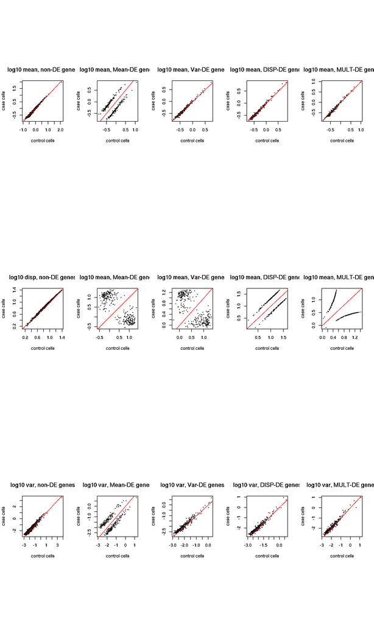

```r
# adjust the read depth with median
ratio.adjust = median(colSums(sample_mean_cases))/median(colSums(sample_mean))
sample_mean_cases = sample_mean_cases/ratio.adjust

# scatter plot

op=par(mfrow = c(3, 5), pty = "s")

plot(log10(apply(sample_mean_ctrls[de.mean + de.var + de.disp + de.mult == 0,], 1, mean)),
     log10(apply(sample_mean_cases[de.mean + de.var + de.disp + de.mult == 0,], 1, mean)),
     cex = .2, xlab = "control cells", ylab = "case cells",
     main = "log10 mean, non-DE genes")
abline(0, 1, col = "red")

plot(log10(apply(sample_mean_ctrls[de.mean== 1,], 1, mean)),
     log10(apply(sample_mean_cases[de.mean== 1,], 1, mean)),
     cex = .2, xlab = "control cells", ylab = "case cells",
     main = "log10 mean, Mean-DE genes")
abline(0, 1, col = "red")

plot(log10(apply(sample_mean_ctrls[de.var== 1,], 1, mean)),
     log10(apply(sample_mean_cases[de.var== 1,], 1, mean)),
     cex = .2, xlab = "control cells", ylab = "case cells",
     main = "log10 mean, Var-DE genes")
abline(0, 1, col = "red")

plot(log10(apply(sample_mean_ctrls[de.disp== 1,], 1, mean)),
     log10(apply(sample_mean_cases[de.disp== 1,], 1, mean)),
     cex = .2, xlab = "control cells", ylab = "case cells",
     main = "log10 mean, DISP-DE genes")
abline(0, 1, col = "red")

plot(log10(apply(sample_mean_ctrls[de.mult== 1,], 1, mean)),
     log10(apply(sample_mean_cases[de.mult== 1,], 1, mean)),
     cex = .2, xlab = "control cells", ylab = "case cells",
     main = "log10 mean, MULT-DE genes")
abline(0, 1, col = "red")

plot(log10(apply(sample_disp_ctrls[de.mean + de.var + de.disp + de.mult == 0,], 1, mean)),
     log10(apply(sample_disp_cases[de.mean + de.var + de.disp + de.mult == 0,], 1, mean)),
     cex = .2, xlab = "control cells", ylab = "case cells",
     main = "log10 disp, non-DE genes")
abline(0, 1, col = "red")

plot(log10(apply(sample_disp_ctrls[de.mean== 1,], 1, mean)),
     log10(apply(sample_disp_cases[de.mean== 1,], 1, mean)),
     cex = .2, xlab = "control cells", ylab = "case cells",
     main = "log10 mean, Mean-DE genes")
abline(0, 1, col = "red")

plot(log10(apply(sample_disp_ctrls[de.var== 1,], 1, mean)),
     log10(apply(sample_disp_cases[de.var== 1,], 1, mean)),
     cex = .2, xlab = "control cells", ylab = "case cells",
     main = "log10 mean, Var-DE genes")
abline(0, 1, col = "red")

plot(log10(apply(sample_disp_ctrls[de.disp== 1,], 1, mean)),
     log10(apply(sample_disp_cases[de.disp== 1,], 1, mean)),
     cex = .2, xlab = "control cells", ylab = "case cells",
     main = "log10 mean, DISP-DE genes")
abline(0, 1, col = "red")

plot(log10(apply(sample_disp_ctrls[de.mult== 1,], 1, mean)),
     log10(apply(sample_disp_cases[de.mult== 1,], 1, mean)),
     cex = .2, xlab = "control cells", ylab = "case cells",
     main = "log10 mean, MULT-DE genes")
abline(0, 1, col = "red")

plot(log10(apply(sample_mean_ctrls[de.mean + de.var + de.disp + de.mult == 0,], 1, var)),
     log10(apply(sample_mean_cases[de.mean + de.var + de.disp + de.mult == 0,], 1, var)),
     cex = .2, xlab = "control cells", ylab = "case cells",
     main = "log10 var, non-DE genes")
abline(0, 1, col = "red")

plot(log10(apply(sample_mean_ctrls[de.mean== 1,], 1, var)),
     log10(apply(sample_mean_cases[de.mean== 1,], 1, var)),
     cex = .2, xlab = "control cells", ylab = "case cells",
     main = "log10 var, Mean-DE genes")
abline(0, 1, col = "red")

plot(log10(apply(sample_mean_ctrls[de.var== 1,], 1, var)),
     log10(apply(sample_mean_cases[de.var== 1,], 1, var)),
     cex = .2, xlab = "control cells", ylab = "case cells",
     main = "log10 var, Var-DE genes")
abline(0, 1, col = "red")

plot(log10(apply(sample_mean_ctrls[de.disp== 1,], 1, var)),
     log10(apply(sample_mean_cases[de.disp== 1,], 1, var)),
     cex = .2, xlab = "control cells", ylab = "case cells",
     main = "log10 var, DISP-DE genes")
abline(0, 1, col = "red")

plot(log10(apply(sample_mean_ctrls[de.mult== 1,], 1, var)),
     log10(apply(sample_mean_cases[de.mult== 1,], 1, var)),
     cex = .2, xlab = "control cells", ylab = "case cells",
     main = "log10 var, MULT-DE genes")
abline(0, 1, col = "red")
```

```r
par(op)
```

## 2.6 simulate scRNAseq based on zinb parameters of cases and controls.

```r
sim_matrix = matrix(nrow = nGeneTotal, ncol = nall * ncell)
date()
```

```
## [1] "Sat Jan  4 20:40:09 2020"
```

```r
for(i in 1:nall){
  idx_i = ((i-1)*ncell+1):(i*ncell)
  for(k in 1:ncell){
    if(HET){
      if(i > nctrl && k > ncell/2 ){
        mean_i = sample_mean_cases[,i-nctrl]
        disp_i = sample_disp_cases[,i-nctrl]
        drop_i = sample_drop_cases[,i-nctrl]
        mean_i[de.mult & case_modify_flag]=mean_i[de.mult & case_modify_flag]+
          mean_i[de.mult & case_modify_flag]*((r_change_prop)/(1-r_change_prop))*rbinom(sum(de.mult & case_modify_flag),1,0.5)
      }else{
        mean_i = sample_mean_ctrls[,i]
        disp_i = sample_disp_ctrls[,i]
        drop_i = sample_drop_ctrls[,i]
        mean_i[de.mult & !case_modify_flag]=mean_i[de.mult & !case_modify_flag]+
          mean_i[de.mult & !case_modify_flag]*((r_change_prop)/(1-r_change_prop))*rbinom(sum(de.mult & !case_modify_flag),1,0.5)
      }
    }
    else{
      if(i > nctrl){
        mean_i = sample_mean_cases[,i-nctrl]
        disp_i = sample_disp_cases[,i-nctrl]
        drop_i = sample_drop_cases[,i-nctrl]
        mean_i[de.mult & case_modify_flag]=mean_i[de.mult & case_modify_flag]+
          mean_i[de.mult & case_modify_flag]*((r_change_prop)/(1-r_change_prop))*rbinom(sum(de.mult & case_modify_flag),1,0.5)
      }else{
        mean_i = sample_mean_ctrls[,i]
        disp_i = sample_disp_ctrls[,i]
        drop_i = sample_drop_ctrls[,i]
        mean_i[de.mult & !case_modify_flag]=mean_i[de.mult & !case_modify_flag]+
          mean_i[de.mult & !case_modify_flag]*((r_change_prop)/(1-r_change_prop))*rbinom(sum(de.mult & !case_modify_flag),1,0.5)
      }
    }

    sample_mean_k = exp(rnorm(nGeneTotal, log(mean_i), sample_log_mean_sd[,i]))

    for (ig in 1:nGeneTotal) {
      sim_matrix[ig,idx_i[k]] = emdbook::rzinbinom(1, sample_mean_k[ig],
                                                   disp_i[ig], drop_i[ig])
    }
  }
}
date()
```

```
## [1] "Sat Jan  4 20:42:47 2020"
```

```r
dim(sim_matrix)
```

```
## [1] 3000 4000
```

```r
sim_matrix[1:4,1:4]
```

```
##      [,1] [,2] [,3] [,4]
## [1,]   64   46   67   62
## [2,]   15   15   25    6
## [3,]    3    8   11   15
## [4,]    5   17   14    5
```

```r
table(c(sim_matrix) == 0)
```

```
##
##   FALSE    TRUE
## 3649028 8350972
```

```r
table(c(sim_matrix) == 0)/(nrow(sim_matrix)*ncol(sim_matrix))
```

```
##
##     FALSE      TRUE
## 0.3040857 0.6959143
```

## 2.7 post simulation: Meta information collection

```r
#the phenotype and individual information of simulated samples.
phenotype = c(rep(0, nctrl * ncell), rep(1, ncase * ncell))
individual = paste0("ind", c(rep(1:nall, each = ncell)))

#Count info for matrix
cell_id = paste0("cell", 1:ncol(sim_matrix))
gene_id = paste0("gene", 1:nrow(sim_matrix))

rownames(sim_matrix) = gene_id
colnames(sim_matrix) = cell_id

#Cell info for meta
cellsum = apply(sim_matrix, 2, sum)
genesum = apply(sim_matrix, 1, sum)
CDR  = apply(sim_matrix > 0, 2, sum) / nrow(sim_matrix)
meta = data.frame(cell_id, individual, phenotype, cellsum, CDR,
                  stringsAsFactors=FALSE)
dim(meta)
```

```
## [1] 4000    5
```

```r
meta[1:2,]
```

```
##       cell_id individual phenotype cellsum       CDR
## cell1   cell1       ind1         0    1210 0.2500000
## cell2   cell2       ind1         0    1125 0.2423333
```

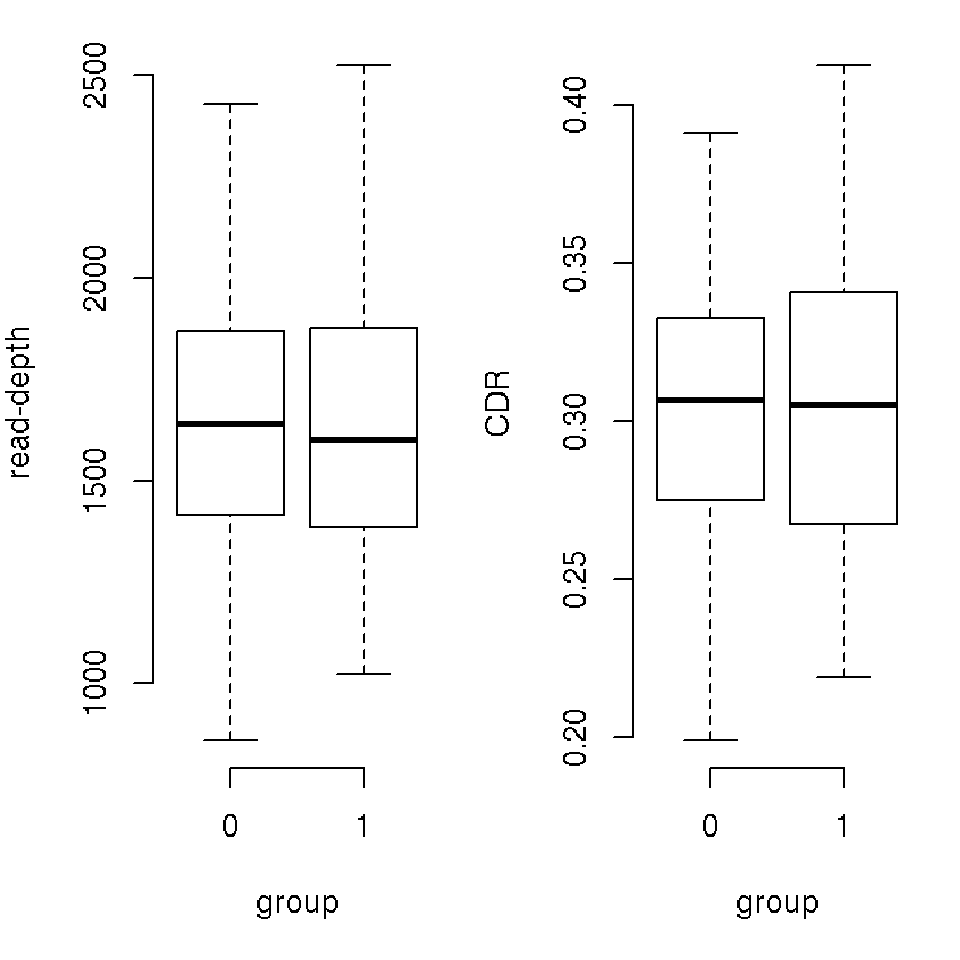

```r
op=par(mfrow=c(1,2), mar=c(5,4,1,1), bty="n")
boxplot(meta$cellsum ~ meta$phenotype, xlab="group", ylab="read-depth")
boxplot(meta$CDR ~ meta$phenotype, xlab="group", ylab="CDR")
```

```r
par(op)
```

## 2.8 post simulation: Some basic stat & Preparation for Bulk RNAseq analysis

```r
# individual level info
cur_individual = unique(meta$individual)
cell_num = matrix(ncol = 1, nrow = length(cur_individual))
rownames(cell_num) = cur_individual
colnames(cell_num) = "cell_num"

read_depth = matrix(ncol = 1, nrow = length(cur_individual))
rownames(read_depth) = cur_individual
colnames(read_depth) = "read_depth"

phenotype_ind = matrix(ncol = 1, nrow = length(cur_individual))
rownames(phenotype_ind) = cur_individual
colnames(phenotype_ind) = "phenotype"

zero_rate_ind = matrix(nrow = nrow(sim_matrix),
                       ncol = length(cur_individual))
rownames(zero_rate_ind) = rownames(sim_matrix)
colnames(zero_rate_ind) = cur_individual

sim_matrix_bulk = matrix(nrow = nrow(sim_matrix),
                         ncol = length(cur_individual))
rownames(sim_matrix_bulk) = rownames(sim_matrix)
colnames(sim_matrix_bulk) = cur_individual

for (i_ind in 1:length(cur_individual)) {
  cur_ind = cur_individual[i_ind]
  #fit org
  cur_ind_m = sim_matrix[, meta$individual == cur_ind]
  cell_num[i_ind]   = ncol(cur_ind_m)
  read_depth[i_ind] = sum(cur_ind_m, na.rm = TRUE) / cell_num[i_ind] * 1000
  phenotype_ind[i_ind] = meta$phenotype[meta$individual == cur_ind][1]

  zero_rate_ind[, i_ind] = rowSums(cur_ind_m == 0, na.rm = TRUE)/cell_num[i_ind]
  sim_matrix_bulk[, i_ind] = rowSums(cur_ind_m, na.rm = TRUE)
}

tapply(read_depth, phenotype_ind, summary)
```

```
## $`0`
##    Min. 1st Qu.  Median    Mean 3rd Qu.    Max.
##  952430 1448425 1630080 1629102 1857882 2128420
##
## $`1`
##    Min. 1st Qu.  Median    Mean 3rd Qu.    Max.
## 1122860 1398428 1600695 1642988 1840478 2329780
```

# 3 Individual level DE analysis: Our Method

## 3.1 Overall of our method

Our method includes 2 parts, the first is calculate the distance between individuals for each gene each cell type. In our method, we use Kullback-Leibler divergence (KL divergence) and the Jensen-Shannon divergence to evaluate the distance between each pair of individuals and use a distance matrix to store that information.

The second parts is estimate the difference between cases and controls based on the distance matrix. We summarized those distance with a pesudo-F statistic and calculate case-control level comparison based on permuation method with two methods: (1). The [Manova](https://onlinelibrary.wiley.com/doi/abs/10.1111/j.1442-9993.2001.01070.pp.x) method developed by Anderson MJ, 2001 (2). The [Permanova-S](https://academic.oup.com/bioinformatics/article/32/17/2618/2450751) method developed by Tang ZZ et al, 2016.

## 3.2 Part I: Calculate the distance matrix with KL divergence/Jensen-Shannon divergence

In our workflow, we provide two kind of method to estimate the distance between individuals of any given genes. The Kullback-Leibler divergence (KL divergence) and the Jensen-Shannon divergence:

suppose we have distribution P and Q Define: M=(P+Q)/2 and D(P||Q)=-sum((P * (log(Q/P)))), then

(1)the Symmetrised Kullback-Leibler divergence: KLmean=1/2 * (D(P||Q)+D(Q||P))

(2)the Jensen-Shannon divergence: JSD=1/2 * (D(P||M)+D(Q||M))

We use dist_array to store the distance between each individuals of each genes.

## 3.3 basic settings

```r
fit_method="empirical" #fit_method = c("zinb","empirical")
dist_method="JSD" #dist_method=c("JSD","mean")

F_method="p" #c("p","ps") for Manova method or Permanova-S method
ind_covariate_flag="ind"  #c(NA, "ind") the individual level covariate for regression, only works for permanova-S method
perm_num=500              #the minimium permutation number.
tol=0.2                   #a factor for threshold settings, p-values no bigger than the threshold(tol/perm_num) will put in a senario with 10 times of permutation size than current situation.

covariate_flag=NA    #cell level covariate flag.
```

## 3.4 Tuning the parameter for difference sample size (OPTIONAL)

To evaluate our method in different sample size, here we provide the code of adjust it. Those parts are only for simulation purpose.

```r
t_sim_matrix=sim_matrix
t_meta=meta

n=20      #c(20,15,10,5)
ncell=100 #c(100,80,60,40,20)

#set labels
selected_index=sample.int(20,n)
total_cell_index=matrix(ncol=1,nrow=0)
for(i_s in c(selected_index,(20+selected_index))){
  cell_index=(100*i_s-ncell+1):(100*i_s)
  total_cell_index=c(total_cell_index,cell_index)
}

#calculation
sim_matrix=t_sim_matrix[,total_cell_index]
meta=t_meta[total_cell_index,]
```

## 3.5 estimate the individual level single cell expression distribution.

To estimate the distribution of individual level we have two methods, one is fitting those counts from each single cells for each gene, each cell type, with ZINB model. Another is getting the empirical density of counts from each single cells for each gene, each cell type. The former method needs an additional step 1. See below.

### 3.5.1 step 1: Fit ZINB for individual level expression (ZINB fitted method Only)

If we fit the distribution of expression on individual level with ZINB we do

```r
cur_individual=unique(meta$individual)
phenotype=meta$phenotype[match(cur_individual,meta$individual)]

op=par(mfrow = c(3, 4), pty = "s")
if(fit_method!="empirical"){
  sim_fit=array(dim=c(nrow(sim_matrix),length(cur_individual),3),
                dimnames = list(rownames(sim_matrix),cur_individual,c("logmean","dispersion","dropout_rate")))

  for(i_g in 1:nrow(sim_matrix)){
    for(i_ind in 1:length(cur_individual)){
      cur_ind=cur_individual[i_ind]
      #fit org
      cur_org_ind=sim_matrix[i_g,meta$individual==cur_ind]

      if(!is.na(covariate_flag)){
        cur_covariate=covariate[meta$individual==cur_ind,]
        sim_fit[i_g,i_ind,]=fit_nbzinb(cur_org_ind,cur_covariate)
      }
      if(is.na(covariate_flag)){
        sim_fit[i_g,i_ind,]=fit_nbzinb(cur_org_ind)
      }

      if(i_g<=3 & i_ind<=4){
        hist(cur_org_ind,main=paste0("Histogram of rawcount, ",rownames(sim_matrix)[i_g]," of ",cur_ind),xlab="Count", ylab = "Frequency")
      }

    }
    if(i_g%%1000==0){
      print(c("ind fit",i_g))
    }
  }

  sim_fit[,,1]=exp(sim_fit[,,1]) #change the log mean to mean!!!
}
par(op)
```

### 3.5.2 step 2: calculate KL/JSD distance

We calculate the KL/JSD between samples based on ZINB fitted individual level expression or empirical individual level distribution. If we fit the distribution of expression with empirical method, we calculate:

```r
if(fit_method=="empirical"){
  dist_array=array(dim=c(nrow(sim_matrix),length(cur_individual),length(cur_individual)),
                   dimnames = list(rownames(sim_matrix),cur_individual,cur_individual))
  for(i_g in 1:nrow(sim_matrix)){
    cur_sim=sim_matrix[i_g,]
    for(i_ind_a in 1:length(cur_individual)){
      for(i_ind_b in 1:length(cur_individual)){
        cur_ind_a=cur_individual[i_ind_a]
        cur_ind_b=cur_individual[i_ind_b]
        #fit sim
        cur_sim_ind_a=as.numeric(cur_sim[meta$individual==cur_ind_a])
        cur_sim_ind_b=as.numeric(cur_sim[meta$individual==cur_ind_b])

        dist_array[i_g,i_ind_a,i_ind_b]=tryCatch(mean_KL_dens(cur_sim_ind_a,cur_sim_ind_b,alter=dist_method,fit_model=fit_method), error = function(e) {NA} )
      }
    }
    if(i_g%%1000==0){
      print(i_g)
    }

  }
}
```

```
## [1] 1000
## [1] 2000
## [1] 3000
```

If we fit the distribution of expression with ZINB model, we calculate:

```r
if(fit_method!="empirical"){
  dist_array=array(dim=c(nrow(sim_fit),length(cur_individual),length(cur_individual)),
                   dimnames = list(rownames(sim_fit),cur_individual,cur_individual))
  for(i_g in 1:nrow(sim_fit)){
    cur_fit=sim_fit[i_g,,]
    for(i_ind_a in 1:length(cur_individual)){
      for(i_ind_b in 1:length(cur_individual)){
        cur_a=cur_fit[i_ind_a,]
        cur_b=cur_fit[i_ind_b,]
        #kl and jsd
        dist_array[i_g,i_ind_a,i_ind_b]=tryCatch(mean_KL_dens(cur_a,cur_b,alter=dist_method,zinb.quantile=0.975,fit_model=fit_method), error = function(e) {NA} )
      }
    }
    if(i_g%%1000==0){
      print(i_g)
    }
  }
}
```

The manova method calculate the pseudo F statistic: Fstat, which testing the null hypothesis of no differences in the positions of the group centroids according to the distance matrix.

Fstat=((sst-ssw)*(n-a))/(ssw*(a-1)) where sst is the total sums of squared distances: sst=sum(dist_matrix*dist_matrix*/(n)) which is the total sum‐of‐squares of distance matrix ssw=sum((dist_matrix*dist_matrix*epsilon)/(n)) which is the sum of within‐group sum‐of‐squares of distance matrix.

n is the total sample numbers, here is case numbers plus control numberrs a is the total group numbers, here if we only have cases and controls, a=2. epsilon is an indicator matrix that the element [i,j]=1 indicates that samples i and j are both in the same group.

(2). The [Permanova-S](https://academic.oup.com/bioinformatics/article/32/17/2618/2450751) method developed by Tang ZZ et al, 2016.

The permanovaS method includes the pseudo F statistic calculation and a high-efficient permutation method.

(i)pseudo F statistic calculation The pseudo F statistic is calculated with Fstat=calTrace(G,H)/calTrace(G,IH),

```r
Fstat=calTrace(G,H)/calTrace(G,IH)
```

where calTrace(H,G) is the function who calculate the trace of the product of matrix (H%*%G%*%H).

```r
library("psych")
calTrace=function(H,G){
  tr(H%*%G%*%H)
}
```

The G is the Gower’s matrix G, which each element g_ij at ith-row, j-column equals to g_ij-row‐means(g_i.)-column‐means(g_.j)+overall mean(g_..)}.

```r
calG=function(m){#m is the distance matrix dim2=dim3=n_individual
  m=m*m
  n=nrow(m)
  res=m+matrix(sum(m)/(n*n),n,n)-1/n *(matrix((rep(rowSums(m),times=n)+rep(colSums(m),each=n)),n,n))
  -1/2*res
}
```

The H is the hat matrix H = X[X’X]^(-1)X’,where defined by the phenotype information X (with n rows representing each individuals and p columns representing features).

```r
calH=function(x){
  x=as.matrix(x)
  x%*% solve(crossprod(x))%*%t(x)
}
```

The IH matrix is defined as

```r
IH=diag(nrow(H))-H
```

If there is covariates matrix, we will removing the confound effect with calculating the residual statistic R. Particularly, we will replace X in the above formula with R0 to calculate the observed pesudo F statistic and replace X in the above formula with R1 to calculate the permutated pseudo F statistic. suppose X is one of phenotype we are interested in, with rows n as individual number and cols p1 as features number. Suppose cur_x is one column of the features. suppose zm is the model matrix generated from phenotype we use as covariates, with rows n as individual number and columns p2 as features number.

The R0 for the observed pseudo F statistic is the column combination of the p1 number of cur_R0, calculated as below:

```r
#for logic model
m1=glm(cur_x~zm,family=binomial(link="logit"))
cur_R0=resid(m1)

#for linear model
m1=lm(cur_x~zm)
cur_R0=resid(m1)
```

For each permutation, we permute the cur_R0 as below and calculate the cur_R1

The R1 for the observed pseudo F statistic is the column combination of the p1 number of cur_R1, calculated as below:

```r
#for logit model
# step1 fit
m1=glm(cur_x~0+zm,family=binomial(link="logit"))  #logit model
cur_res=resid(m1)  #cal residuals
cur_fit=fitted(m1) #cal fit
#step2: permutation
perm_x=rbinom(length(cur_fit),1,prob=cur_fit)
m2=glm(perm_x~zm,family=binomial(link="logit"))
cur_R1=resid(m2)

#for linear model
#step1: fit
m1=lm(cur_x~0+zm)  #linear model
cur_res=resid(m1) #cal residuals
cur_fit=fitted(m1) #cal fit
#step2: permutation
perm_x=cur_res[sample.int(length(cur_res),length(cur_res))]+cur_fit
m2=lm(perm_x~zm)  #logit model
cur_R1=resid(m2)  #cal residuals
```

(ii)permutation method According to [Permanova-S](https://academic.oup.com/bioinformatics/article/32/17/2618/2450751), we will start from a small permutation number,say, perm_num.min=500, and set a threshold thres=tol/perm_num.min where the tol ranges from 0 to 1. Each turn, we re-do the calculation of p-values who is no bigger than the thres with increasing the permutation number 10 times. In this object, we stop when the perm_num.min increases 1000 times, say, perm_num.min=5e+5. Since in each iteration, we calculate the p-values who’s less than the threshold independently, our p-value results will be more conservative than it actually been.

### 3.6.1 covariates of Permanova-S

In practice, the permanova-S can be individual level covariates, and the input of covariates of our function is a model matrix,covariate_model_matrix, from the covariate dataframe, which have each row represents the individuals and each column represents the features. See below to find the methods If we don’t specify covariate_model_matrix, the covariate will be settled as a vector who lengths as the individual number with all element equals to 1.

```r
#set covariate
if(is.na(ind_covariate_flag)){
  covariate_model_matrix=NA
}
if(ind_covariate_flag=="ind"){
  CDR=1-apply(zero_rate_ind==0,2,sum)/nrow(zero_rate_ind)
  cur_covariate=data.frame(cbind(read_depth,CDR))
  rownames(cur_covariate)=cur_individual
  colnames(cur_covariate)=c("read_depth","CDR")
  covariate_model_matrix=model.matrix(~.,cur_covariate)
}
```

We wrote the function cal_permanova_pval/cal_permanova_pval2 for implementation of single round of permutation. The input of cal_permanova_pval is a symmetric square matrix for distance(KL divergence/JSD) between each pair of individuals for one gene.The input of cal_permanova_pval is a 3-dementional array wich the 1st demension represents each gene, the 2nd and 3rd demension is the symmetric square matrix for distance(KL divergence/JSD) between each pair of individuals.

Please see file 9.0_Fstat_functions.R for the code details.

```r
dist_pval=cal_permanova_pval2(dist_array,phenotype,perm_num.min = perm_num,Fstat_method=F_method,zm=covariate_model_matrix)
thres=tol/perm_num
second_index=which(dist_pval<thres)
if(length(second_index)>0){
  sub_dist_array=dist_array[second_index,,,drop=FALSE]
  sub_dist_pval=cal_permanova_pval2(sub_dist_array,phenotype,perm_num.min = perm_num*10,Fstat_method=F_method,zm=covariate_model_matrix)
  dist_pval[second_index]=sub_dist_pval
  thres=tol/(perm_num*10)
  second_index=which(dist_pval<thres)
  if(length(second_index)>0){
    sub_dist_array=dist_array[second_index,,,drop=FALSE]
    sub_dist_pval=cal_permanova_pval2(sub_dist_array,phenotype,perm_num.min = perm_num*100,Fstat_method=F_method,zm=covariate_model_matrix)
    dist_pval[second_index]=sub_dist_pval
    thres=tol/(perm_num*100)
    second_index=which(dist_pval<thres)
    if(length(second_index)>0){
      sub_dist_array=dist_array[second_index,,,drop=FALSE]
      sub_dist_pval=cal_permanova_pval2(sub_dist_array,phenotype,perm_num.min = perm_num*1000,Fstat_method=F_method,zm=covariate_model_matrix)
      dist_pval[second_index]=sub_dist_pval
    }
  }
}

dist_pval[1:10]
```

```
##  gene1  gene2  gene3  gene4  gene5  gene6  gene7  gene8  gene9 gene10
##  0.254  0.170  0.978  0.278  0.050  0.260  0.274  0.204  0.100  0.838
```

# 4 Individual level DE analysis: Compare with other method

## 4.1 DESeq2

```r
cur_info = meta[, c("individual", "phenotype")]
cur_info = unique(cur_info)
rownames(cur_info) = cur_info$individual
cur_info$phenotype = as.factor(cur_info$phenotype)

# object construction
dds = DESeqDataSetFromMatrix(countData = sim_matrix_bulk,
                               colData = cur_info,
                               design = ~ phenotype)

# observed pvalue calculation
dds = DESeq(dds)
deseq_pval = results(dds)$pvalue
head(deseq_pval)
```

```
## [1] 0.098899989 0.002135463 0.830111485 0.102598885 0.001307906 0.048354433
```

## 4.2 MAST

```r
library("moments")
sim_matrix_log = log2(1 + sim_matrix)


dim(sim_matrix_log)
```

```
## [1] 3000 4000
```

```r
sim_matrix_log[1:10,1:10]
```

```
##           cell1    cell2    cell3    cell4    cell5    cell6    cell7
## gene1  6.022368 5.554589 6.087463 5.977280 5.700440 6.169925 5.554589
## gene2  4.000000 4.000000 4.700440 2.807355 4.087463 3.906891 2.807355
## gene3  2.000000 3.169925 3.584963 4.000000 4.169925 4.087463 5.044394
## gene4  2.584963 4.169925 3.906891 2.584963 3.700440 3.584963 2.321928
## gene5  2.584963 1.000000 0.000000 2.807355 2.584963 1.584963 2.807355
## gene6  2.321928 1.000000 1.584963 2.584963 3.700440 1.584963 1.584963
## gene7  3.321928 1.584963 2.807355 3.169925 1.000000 2.807355 2.584963
## gene8  2.584963 2.321928 2.807355 1.584963 2.321928 2.321928 1.000000
## gene9  2.584963 0.000000 1.000000 0.000000 3.000000 2.321928 3.169925
## gene10 2.807355 0.000000 3.321928 1.584963 3.000000 0.000000 1.584963
##           cell8    cell9   cell10
## gene1  5.087463 6.087463 6.000000
## gene2  4.000000 3.807355 3.000000
## gene3  3.584963 4.000000 4.169925
## gene4  3.807355 3.700440 2.584963
## gene5  1.584963 2.584963 2.321928
## gene6  2.584963 0.000000 0.000000
## gene7  2.321928 3.000000 3.459432
## gene8  2.000000 1.000000 1.584963
## gene9  2.321928 3.169925 1.000000
## gene10 1.584963 0.000000 1.000000
```

```r
cell_id = colnames(sim_matrix_log)   #get the cell id from the data
gene_id = rownames(sim_matrix_log)   #get the gene id from the data

library("MAST")
library("lme4")

fData=data.frame(primerid=gene_id)
cData=data.frame(wellKey=cell_id)
colnames(meta)
```

```
## [1] "cell_id"    "individual" "phenotype"  "cellsum"    "CDR"
```

```r
dim(meta)
```

```
## [1] 4000    5
```

```r
head(meta)
```

```
##       cell_id individual phenotype cellsum       CDR
## cell1   cell1       ind1         0    1210 0.2500000
## cell2   cell2       ind1         0    1125 0.2423333
## cell3   cell3       ind1         0    1168 0.2406667
## cell4   cell4       ind1         0    1237 0.2460000
## cell5   cell5       ind1         0    1162 0.2443333
## cell6   cell6       ind1         0    1156 0.2396667
```

```r
length(fData)
```

```
## [1] 1
```

```r
length(cData)
```

```
## [1] 1
```

```r
sca=FromMatrix(sim_matrix_log, cData, fData)
colData(sca)$cngeneson = as.numeric(meta$CDR)
colData(sca)$diagnosis =as.factor(meta$phenotype)
colData(sca)$ind = as.factor(meta$individual)

colData(sca)
```

```
## DataFrame with 4000 rows and 4 columns
##              wellKey         cngeneson diagnosis      ind
##          <character>         <numeric>  <factor> <factor>
## cell1          cell1              0.25         0     ind1
## cell2          cell2 0.242333333333333         0     ind1
## cell3          cell3 0.240666666666667         0     ind1
## cell4          cell4             0.246         0     ind1
## cell5          cell5 0.244333333333333         0     ind1
## ...              ...               ...       ...      ...
## cell3996    cell3996 0.335333333333333         1    ind40
## cell3997    cell3997             0.333         1    ind40
## cell3998    cell3998 0.349666666666667         1    ind40
## cell3999    cell3999             0.343         1    ind40
## cell4000    cell4000              0.32         1    ind40
```

```r
date()
```

```
## [1] "Sun Jan  5 00:01:16 2020"
```